# COVID_economic_analysis

Jesus Sanchez

2022-09-05

Let’s first load our packages

```r
library(tidyverse)
library(readxl)
```

Then, using the “readx1” package we’ll load our data

```r
covid_2022 <- read.csv("covid_data_04_09_2022.csv")
covid_2020 <- read.csv("covid_data_20_01_2020.csv")
gdp_rate <- read.csv("GDP Growth Rate by Country.csv")
gdp_per_capita <- read.csv("GDP Per Capita by Country.csv")
infation <- read.csv("Inflation Rate by Country.csv")
```

#Procesing data

We want to analyze if there is a correlation between COVID and some economic metrics. In order to get it, we have to merge our 4 data frames in just one.

```r
covid_2020 <- covid_2020 %>% rename(Country.Name=Country.Region)
covid_2022 <- covid_2022 %>% rename(Country.Name=Country..Other)
#We start by renaming one column to use the merge function
```

Before we merge our data, we have to make the rows names be the same, in order to get it we’ll change some abbreviate names

```r
covid_2020[covid_2020=="USA"] <- "United States"
covid_2020[covid_2020=="S. Korea"] <- "South Korea"
covid_2020[covid_2020=="UK"] <- "United Kingdom"
covid_2022[covid_2022=="USA"] <- "United States"
covid_2022[covid_2022=="S. Korea"] <- "South Korea"
covid_2022[covid_2022=="UK"] <- "United Kingdom"
```

```r
all_togheter_2020 <- merge(x = covid_2020,
                             y = gdp_rate, by="Country.Name",
                             all=T)
all_togheter_2020 <- merge(x=all_togheter_2020,
                      y=gdp_per_capita, by ="Country.Name",
                      all=T)
all_togheter_2020 <- merge(x=all_togheter_2020,
                      y=infation, by="Country.Name",
                      all=T)

#we do the same with data from 2022
all_togheter_2022 <- merge(x = covid_2022,
                             y = gdp_rate, by="Country.Name",
                             all=T)
all_togheter_2022 <- merge(x=all_togheter_2022,
                      y=gdp_per_capita, by ="Country.Name",
                      all=T)
all_togheter_2022 <- merge(x=all_togheter_2022,
                      y=infation, by="Country.Name",
                      all=T)
```

#Cleaning data

We have merged our data, but now the column names are not readables, we don’t know what is the gdp_rate, gdp_per capita and the inflation rate. So, let’s change the column labels

```r
colnames(all_togheter_2022) #first we visualize the colum names
```

```
##  [1] "Country.Name"      "X."                "Total.Cases"
##  [4] "New.Cases"         "Total.Deaths"      "New.Deaths"
##  [7] "Total.Recovered"   "New.Recovered"     "Active.Cases"
## [10] "Serious..Critical" "Tot.Cases..1M.pop" "Deaths..1M.pop"
## [13] "Total.Tests"       "Tests...1M.pop"    "Population"
## [16] "X2021.x"           "X2020.x"           "X2019.x"
## [19] "X2018.x"           "X2017.x"           "X2021.y"
## [22] "X2020.y"           "X2019.y"           "X2018.y"
## [25] "X2017.y"           "X2021"             "X2020"
## [28] "X2019"             "X2018"             "X2017"
```

```r
head(all_togheter_2022) #display the first rows
```

```
##     Country.Name  X. Total.Cases New.Cases Total.Deaths New.Deaths
## 1                 NA         721        NA           15         NA
## 2    Afghanistan 117      194163        NA         7782         NA
## 3         Africa  NA    12616085        NA       257418         NA
## 4        Albania 101      330193        NA         3582         NA
## 5        Algeria 105      270443        NA         6879         NA
## 6 American Samoa  NA          NA        NA           NA         NA
##   Total.Recovered New.Recovered Active.Cases Serious..Critical
## 1             706                          0                 0
## 2         172,168                     14,213              1124
## 3      11,943,257                    415,410              1026
## 4         322,849                      3,762                NA
## 5         182,067                     81,497                 6
## 6            <NA>          <NA>         <NA>                NA
##   Tot.Cases..1M.pop Deaths..1M.pop Total.Tests Tests...1M.pop Population
```

[output cut: 20 more lines]

```r
filter(gdp_per_capita,Country.Name=="Afghanistan")
```

```
##   Country.Name X2021 X2020 X2019 X2018 X2017
## 1  Afghanistan     0   517   494   486   517
```

```r
filter(gdp_rate, Country.Name=="Afghanistan")
```

```
##   Country.Name X2021   X2020  X2019  X2018  X2017
## 1  Afghanistan     0 -0.0235 0.0391 0.0119 0.0265
```

```r
filter(infation, Country.Name=="Afghanistan")
```

```
##   Country.Name X2021 X2020 X2019  X2018  X2017
## 1  Afghanistan     0     0 0.023 0.0063 0.0498
```

```r
#filter the Afghanistan row to match the columns with their real name
all_togheter_2020 <- rename(all_togheter_2020,
                            "gdp_per_capita_2021"="X2021.y",
       "gdp_per_capita_2020"="X2020.y",
       "gdp_per_capita_2019"="X2019.y",
       "gdp_per_capita_2018"="X2018.y",
       "gdp_per_capita_2017"="X2017.y",
       "gdp_rate_2021"="X2021.x",
       "gdp_rate_2020"="X2020.x",
       "gdp_rate_2019"="X2019.x",
       "gdp_rate_2018"="X2018.x",
       "gdp_rate_2017"="X2017.x",
       "inflation_rate_2021"="X2021",
       "inflation_rate_2020"="X2020",
       "inflation_rate_2019"="X2019",
       "inflation_rate_2018"="X2018",
       "inflation_rate_2017"="X2017")
#renaming columns from 2020 data

all_togheter_2022 <- rename(all_togheter_2022,
                            "gdp_per_capita_2021"="X2021.y",
       "gdp_per_capita_2020"="X2020.y",
       "gdp_per_capita_2019"="X2019.y",
       "gdp_per_capita_2018"="X2018.y",
       "gdp_per_capita_2017"="X2017.y",
       "gdp_rate_2021"="X2021.x",
       "gdp_rate_2020"="X2020.x",
       "gdp_rate_2019"="X2019.x",
       "gdp_rate_2018"="X2018.x",
       "gdp_rate_2017"="X2017.x",
       "inflation_rate_2021"="X2021",
       "inflation_rate_2020"="X2020",
       "inflation_rate_2019"="X2019",
       "inflation_rate_2018"="X2018",
       "inflation_rate_2017"="X2017")
#renaming columns from 2022 data

all_togheter_2022 %>%
  filter(Country.Name %in% c("Europe", "Africa", "South America",
                             "Oceania", "Asia", "North America",
                             "Total:", "World")) #analizing what rows we will delete
```

```
##     Country.Name X. Total.Cases New.Cases Total.Deaths New.Deaths
## 1         Africa NA    12616085        NA       257418         NA
## 2           Asia NA   184743469     39257      1469343         78
## 3         Europe NA   222253960        NA      1904758         NA
## 4  North America NA   114689858       990      1526246          5
## 5        Oceania NA    12191895      5539        19637         10
## 6  South America NA    63731409        NA      1326129         NA
## 7         Total: NA    12616085        NA       257418         NA
## 8         Total: NA    12191895      5539        19637         10
## 9         Total: NA   222253960        NA      1904758         NA
## 10        Total: NA   184743469     39257      1469343         78
## 11        Total: NA   610227397     45786      6503546         93
## 12        Total: NA   114689858       990      1526246          5
## 13        Total: NA    63731409        NA      1326129         NA
## 14        Total: NA         721        NA           15         NA
```

[output cut: 113 more lines]

```r
all_togheter_2022 <-all_togheter_2022 %>%
  filter(!Country.Name %in% c("Europe", "Africa", "South America",
                             "Oceania", "Asia", "North America",
                             "Total:", "World"))
#finally, let's remove some columns that have general metric by region
```

Now that we have our data, it’s time to make our analysis

#Analysis

```r
data_2020 <- all_togheter_2020 %>%
  arrange(desc(TotalCases)) %>%
  slice(1:20) # Top 20 highest TotalCases by country 2020


data_2022 <- all_togheter_2022 %>%
  arrange(desc(Total.Cases)) %>%
  slice(1:20) # Top 20 highest TotalCases by country 2022
```

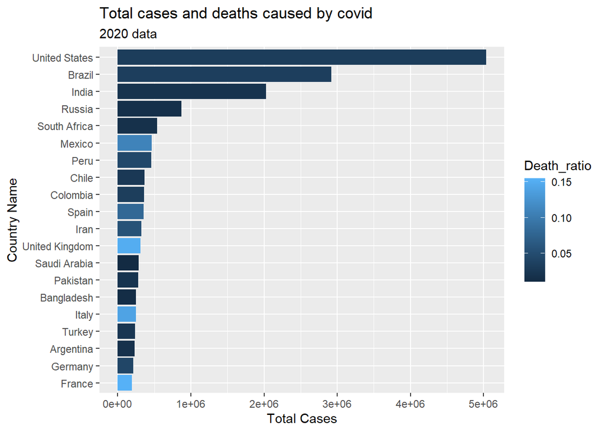

```r
data_2020 <- mutate(data_2020, Death_ratio=TotalDeaths/TotalCases)
#we created in a first step our new Death_ratio column
data_2020 %>% ggplot(aes(x=reorder(Country.Name, +TotalCases), TotalCases, fill=Death_ratio)) +
  geom_bar(stat="identity", position="stack")+
  labs(x="Country Name", y="Total Cases",
       title="Total cases and deaths caused by covid",
       subtitle="2020 data") + coord_flip()
```

Now we analize the same but with data from 2022

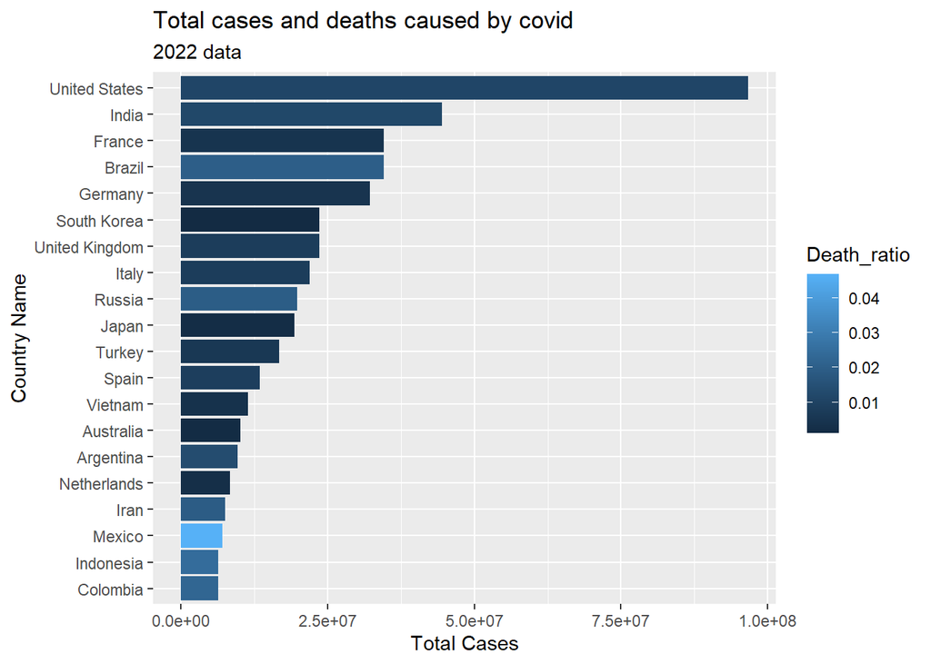

```r
data_2022 <- mutate(data_2022, Death_ratio=Total.Deaths/Total.Cases)
#we created in a first step our new Death_ratio column
data_2022 %>% ggplot(aes(x=reorder(Country.Name, +Total.Cases), Total.Cases, fill=Death_ratio)) +
  geom_bar(stat="identity", position="stack")+
  labs(x="Country Name", y="Total Cases",
       title="Total cases and deaths caused by covid",
       subtitle="2022 data") + coord_flip()
```

Comparing data from 2020 and 2022 Changing the colnames to make data_2022 and data_2020 can match. And merge their rows

```r
colnames(data_2020)
```

```
##  [1] "Country.Name"        "Continent"           "Population"
##  [4] "TotalCases"          "NewCases"            "TotalDeaths"
##  [7] "NewDeaths"           "TotalRecovered"      "NewRecovered"
## [10] "ActiveCases"         "Serious.Critical"    "Tot.Cases.1M.pop"
## [13] "Deaths.1M.pop"       "TotalTests"          "Tests.1M.pop"
## [16] "WHO.Region"          "gdp_rate_2021"       "gdp_rate_2020"
## [19] "gdp_rate_2019"       "gdp_rate_2018"       "gdp_rate_2017"
## [22] "gdp_per_capita_2021" "gdp_per_capita_2020" "gdp_per_capita_2019"
## [25] "gdp_per_capita_2018" "gdp_per_capita_2017" "inflation_rate_2021"
## [28] "inflation_rate_2020" "inflation_rate_2019" "inflation_rate_2018"
## [31] "inflation_rate_2017" "Death_ratio"
```

```r
colnames(data_2022)
```

```
##  [1] "Country.Name"        "X."                  "Total.Cases"
##  [4] "New.Cases"           "Total.Deaths"        "New.Deaths"
##  [7] "Total.Recovered"     "New.Recovered"       "Active.Cases"
## [10] "Serious..Critical"   "Tot.Cases..1M.pop"   "Deaths..1M.pop"
## [13] "Total.Tests"         "Tests...1M.pop"      "Population"
## [16] "gdp_rate_2021"       "gdp_rate_2020"       "gdp_rate_2019"
## [19] "gdp_rate_2018"       "gdp_rate_2017"       "gdp_per_capita_2021"
## [22] "gdp_per_capita_2020" "gdp_per_capita_2019" "gdp_per_capita_2018"
## [25] "gdp_per_capita_2017" "inflation_rate_2021" "inflation_rate_2020"
## [28] "inflation_rate_2019" "inflation_rate_2018" "inflation_rate_2017"
## [31] "Death_ratio"
```

```r
data_2020 <- select(data_2020, -Continent, WHO.Region,-NewRecovered, -NewDeaths, -TotalRecovered,
                    NewCases, -ActiveCases, -ActiveCases)
data_2022 <- select(data_2022, -New.Recovered, -New.Deaths, -Total.Recovered,
                    New.Cases, -Active.Cases, -Active.Cases)
data_2022 <- data_2022[,-2]

data_2020 <-data_2020 %>% rename(Total.Cases=TotalCases,
                     Total.Deaths=TotalDeaths,
                     Serious..Critical=Serious.Critical,
                     Tot.Cases..1M.pop=Tot.Cases.1M.pop,
                     Deaths..1M.pop=Deaths.1M.pop,
                     Total.Tests=TotalTests,
                     Tests...1M.pop=Tests.1M.pop,
                     Deaths..1M.pop=Deaths.1M.pop
                     )

all_data <- bind_rows(data_2020, data_2022)
```

[figure not shown]

```r
all_data %>% ggplot(aes(x=reorder(Country.Name, +Total.Cases), Total.Cases, fill=Death_ratio)) +
  geom_bar(stat="identity", position="stack")+
  labs(x="Country Name", y="Total Cases",
       title="Total cases and deaths caused by covid",
       subtitle="2022 data") + coord_flip()
```

But, there’s a relationship between COVID and the gdp per capita in 2020? Let’s make a linear regression analysis to have an answer.

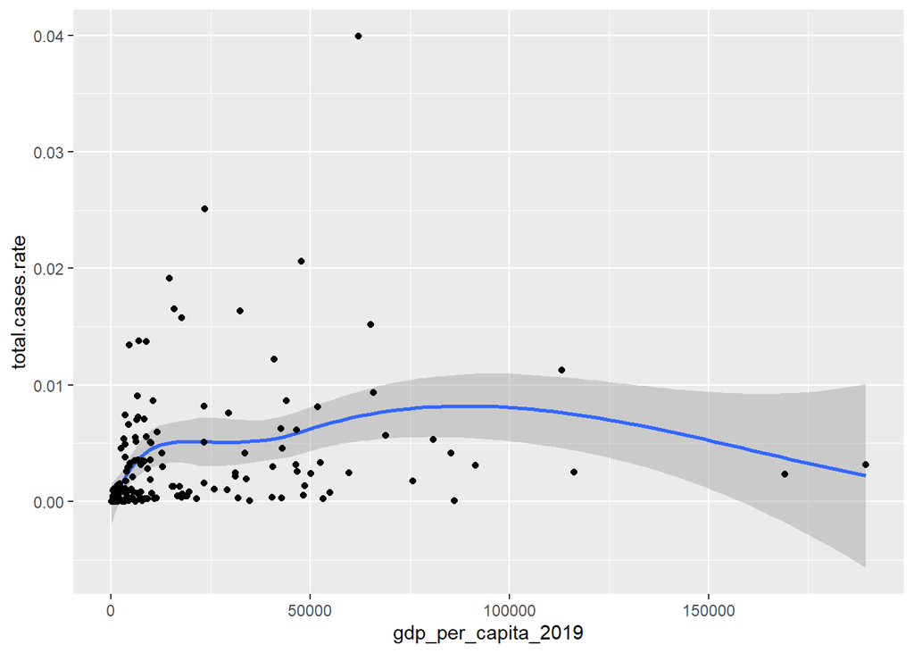

```r
all_togheter_2020 <- mutate(all_togheter_2020,                  total.cases.rate=TotalCases/Population)
#first we standarize our variable, having a relation between total cases and population by country, in order to make a fair analysis

all_togheter_2020 %>% ggplot() +
  geom_smooth(aes(gdp_per_capita_2019, total.cases.rate))+
  geom_point(aes(gdp_per_capita_2019, total.cases.rate))
```

```r
all_togheter_2020 %>% lm(formula=total.cases.rate ~gdp_per_capita_2019) %>%
  summary()
```

```
##
## Call:
## lm(formula = total.cases.rate ~ gdp_per_capita_2019, data = .)
##
## Residuals:
##       Min        1Q    Median        3Q       Max
## -0.007329 -0.002458 -0.001863  0.000711  0.034830
##
## Coefficients:
##                      Estimate Std. Error t value Pr(>|t|)
## (Intercept)         2.450e-03  4.746e-04   5.161 6.95e-07 ***
## gdp_per_capita_2019 4.255e-08  1.355e-08   3.139  0.00201 **
## ---
## Signif. codes:  0 '***' 0.001 '**' 0.01 '*' 0.05 '.' 0.1 ' ' 1
##
## Residual standard error: 0.005111 on 166 degrees of freedom
##   (81 observations deleted due to missingness)
## Multiple R-squared:  0.05603,    Adjusted R-squared:  0.05034
## F-statistic: 9.853 on 1 and 166 DF,  p-value: 0.002007
```

```r
all_togheter_2020 %>% lm(formula=gdp_per_capita_2019~total.cases.rate) %>%
  summary()
```

```
##
## Call:
## lm(formula = gdp_per_capita_2019 ~ total.cases.rate, data = .)
##
## Residuals:
##    Min     1Q Median     3Q    Max
## -28259 -14655 -11770   3614 170124
##
## Coefficients:
##                  Estimate Std. Error t value Pr(>|t|)
## (Intercept)         15172       2589   5.859 2.44e-08 ***
## total.cases.rate  1316858     419524   3.139  0.00201 **
## ---
## Signif. codes:  0 '***' 0.001 '**' 0.01 '*' 0.05 '.' 0.1 ' ' 1
##
## Residual standard error: 28440 on 166 degrees of freedom
##   (81 observations deleted due to missingness)
## Multiple R-squared:  0.05603,    Adjusted R-squared:  0.05034
## F-statistic: 9.853 on 1 and 166 DF,  p-value: 0.002007
```

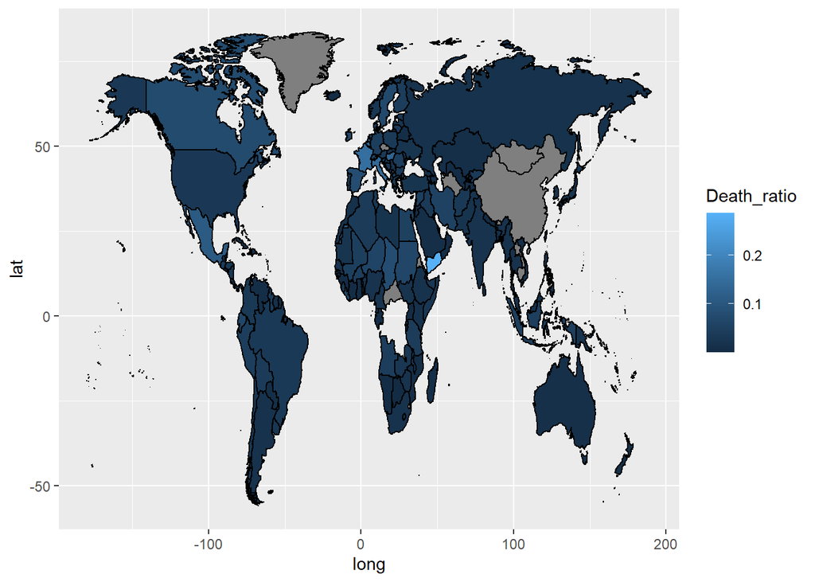

```r
mapdata <- map_data("world")
mapdata <- mapdata %>% rename("Country.Name" = "region")
mapdata[mapdata=="USA"] <- "United States"
all_togheter_2020 <- mutate(all_togheter_2020,
                   Death_ratio=TotalDeaths/TotalCases)

map_data <- right_join(mapdata, all_togheter_2020, by="Country.Name")

ggplot(map_data, aes(long, lat, group=group))+
  geom_polygon(aes(fill=Death_ratio), color="black")
```

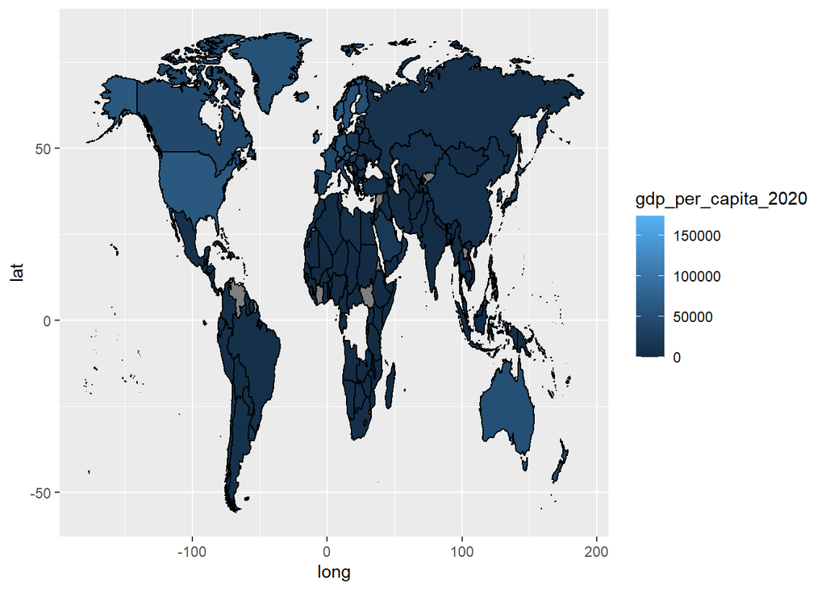

```r
ggplot(map_data, aes(long, lat, group=group))+
  geom_polygon(aes(fill=gdp_per_capita_2020), color="black")
```